# Lecture 322

2021-10-03

## Multiple Regression

## Recap

**Prev**: Simple Regression

- Regression
- Ordinary Least Squares
- Interpretation
- Checking assumptions

**Now**: Multiple Regression

- Multiple regression
- Interpretation
- Checking assumptions

## Multiple regression

**Regression analysis** is a supervised machine learning approach

Special case of the general linear model

\[outcome_i = (model) + error_i \]

Predict (estimate) value of one outcome (dependent) variable as

- one predictor (independent) variable: **simple / univariate**

\[Y_i = (b_0 + b_1 * X_{i1}) + \epsilon_i \]

- more predictor (independent) variables: **multiple / multivar.**

\[Y_i = (b_0 + b_1 * X_{i1} + b_2 * X_{i2} + \dots + b_M * X_{iM}) + \epsilon_i \]

## Assumptions

- **Linearity**
  - the relationship is actually linear
- **Normality** of residuals
  - standard residuals are normally distributed with mean `0`
- **Homoscedasticity** of residuals
  - at each level of the predictor variable(s) the variance of the standard residuals should be the same (*homo-scedasticity*) rather than different (*hetero-scedasticity*)
- **Independence** of residuals
  - adjacent standard residuals are not correlated
- When more than one predictor: **no multicollinearity**
  - if two or more predictor variables are used in the model, each pair of variables not correlated

## Boston housing

A classic R dataset

- price of houses in Boston
- in relation to:
  - house characteristics
  - neighborhood
  - air quality

Harrison, D., and D. L. Rubinfeld. 1978. Hedonic Housing Prices and the Demand for Clean Air. Journal of Environmental Economics and Management 5 (1): 81–102.

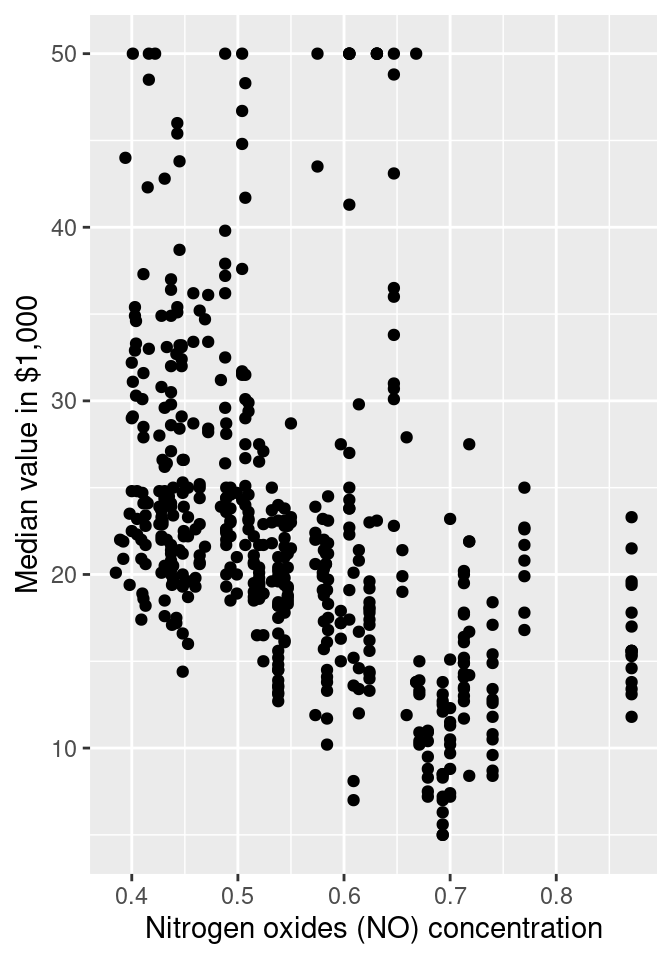

## Example

Can we predict price based on number of rooms and air quality?

\[house\ value_i = (b_0 + b_1 * rooms_{i} + b_2 * NO\ conc_{i}) + \epsilon_i \]

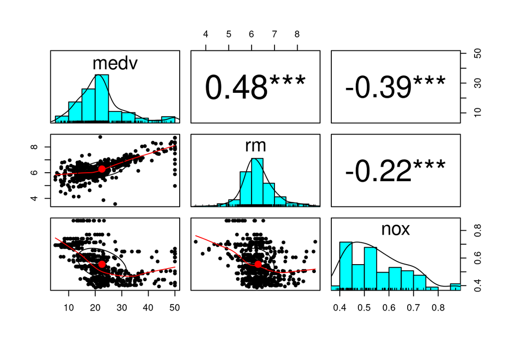

## stats::lm

```r
MASS::Boston %$%
  stats::lm(medv ~ rm + nox) ->
  medv_model

medv_model %>%
  summary()
```

```
##
## Call:
## stats::lm(formula = medv ~ rm + nox)
##
## Residuals:
##     Min      1Q  Median      3Q     Max
## -17.889  -3.287  -0.636   2.518  39.638
##
## Coefficients:
##             Estimate Std. Error t value Pr(>|t|)
## (Intercept) -18.2059     3.3393  -5.452 7.82e-08 ***
## rm            8.1567     0.4173  19.546  < 2e-16 ***
## nox         -18.9706     2.5304  -7.497 2.97e-13 ***
## ---
## Signif. codes:  0 '***' 0.001 '**' 0.01 '*' 0.05 '.' 0.1 ' ' 1
##
## Residual standard error: 6.281 on 503 degrees of freedom
## Multiple R-squared:  0.5354, Adjusted R-squared:  0.5336
## F-statistic: 289.9 on 2 and 503 DF,  p-value: < 2.2e-16
```

## Standardised coefficients

- Indicate amount of change
  - in the outcome variable
  - per one standard deviation change in the predictor variable
- Can also be interpreted as importance of predictor

```r
medv_model %>%
  lm.beta::lm.beta()
```

```
##
## Call:
## stats::lm(formula = medv ~ rm + nox)
##
## Standardized Coefficients::
## (Intercept)          rm         nox
##   0.0000000   0.6231316  -0.2390178
```

## Confindence intervals

- Coefficients’ 95% confidence intervals
  - can be interpreted as interval containing true coefficient values
  - good models should result in small intervals

```r
medv_model %>%
  stats::confint()
```

```
##                 2.5 %     97.5 %
## (Intercept) -24.76666 -11.645106
## rm            7.33676   8.976551
## nox         -23.94200 -13.999233
```

## Outliers and influential cases

```r
MASS::Boston %>%
  mutate(
    model_stdres = medv_model %>% stats::rstandard(),
    model_cook_dist = medv_model %>% stats::cooks.distance()
  ) ->
  boston_output

boston_output %>%
  dplyr::select(medv, model_stdres, model_cook_dist) %>%
  dplyr::filter(abs(model_stdres) > 2.58 | model_cook_dist > 1)
```

```
##    medv model_stdres model_cook_dist
## 1  50.0     2.975511      0.02911770
## 2  21.9    -2.907328      0.11856922
## 3  27.5     4.899644      0.26329818
## 4  23.1     3.511137      0.10891047
## 5  50.0     6.339016      0.12065579
## 6  50.0     4.094574      0.02308311
## 7  50.0     3.665060      0.02786674
## 8  50.0     4.699311      0.02109333
## 9  50.0     5.257825      0.03746931
## 10  7.5    -2.672594      0.01576071
```

No influential cases (Cook’s distance `> 1`) but there are many outliers (7 abs std res `> 3.29`, 2% `> 2.58`)

## Checking assumptions: normality

Shapiro-Wilk test for normality of standard residuals,

- robust models: should be **not** significant

```r
boston_output %$%
  stats::shapiro.test(
    model_stdres
  )
```

```
##
##  Shapiro-Wilk normality test
##
## data:  model_stdres
## W = 0.8979, p-value < 2.2e-16
```

**Standard residuals are NOT normally distributed**

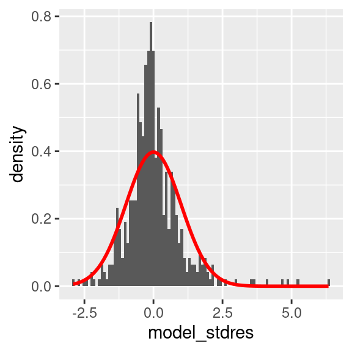

## Checking assumpt.: homoscedasticity

Breusch-Pagan test for homoscedasticity of standard residuals

- robust models: should be **not** significant

```r
medv_model %>%
  lmtest::bptest()
```

```
##
##  studentized Breusch-Pagan test
##
## data:  .
## BP = 22.342, df = 2, p-value = 1.407e-05
```

**Standard residuals are NOT homoscedastic**

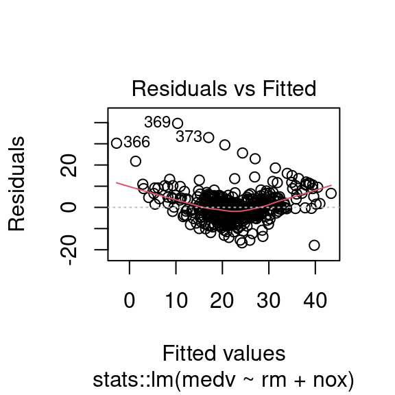

## Checking assumptions: independence

Durbin-Watson test for the independence of residuals

- robust models: statistic should be close to 2 (advised between 1 and 3) and **not** significant

```r
medv_model %>%
  lmtest::dwtest()
```

```
##
##  Durbin-Watson test
##
## data:  .
## DW = 0.68451, p-value < 2.2e-16
## alternative hypothesis: true autocorrelation is greater than 0
```

**Standard residuals are NOT independent**

Note: the result depends on the order of the data.

## Checking assumpt.: multicollinearity

Checking the variance inflation factor (VIF)

```r
library(car)

medv_model %>%
  car::vif()
```

```
##       rm      nox
## 1.100495 1.100495
```

**There is no multicollinearity**

## Example

No, we can’t predict house prices based only on number of rooms and air quality.

- predictors are statistically significant
- but model is not robust, as it doesn’t satisfy most assumptions
  - Standard residuals are NOT normally distributed
  - Standard residuals are NOT homoscedastic
  - Standard residuals are NOT independent
  - (although there is no multicollinearity)

We seem to be on the right path, but something is missing…

## Summary

Multiple Regression

- Multiple regression
- Interpretation
- Checking assumptions

**Next**: Comparing regression models

- Information criteria
- Model difference
- Systematic variable choice